# Examples from **plot_directory_ASV.R**

Overwiew of the plots that can be obtained with the R script *plot_directory_ASV.R*.  
The user is supposed to run only the part of the codes that are suitable for his dataset, and in this markdown it’s possible to have an overwiew of the outputs from the different chunks of code of the R script. ´

# Inserting the data

Insert the path to the results directory in *path*. In *results_dir* add the name of the directory in the results folder where the ASVs have been separated by species. This directory is created with the python script *extracting_asvs.py*. **Important** all the plots will be saved inside results, inside a folder called *plots*.

```r
path <- "/home/valentina_galeone/Desktop/github_rep/metabarcoding/results/"
results_dir <- "seqtab_nonchim_id_ASV"
path_result <- paste(path, results_dir, "/", sep = "")
setwd(path_result)
```

Modify this variable to True if you want to normalize the plots by the value of the highest peak in the ASV.

```r
norm <- FALSE
```

Optionally, insert here a file where the name of the samples in Dada2 output (SAMPLE_NAME) is associated with a Date, an Order and/or a Group (more later).

```r
label_file <- "/home/valentina_galeone/Desktop/github_rep/metabarcoding/Data/sample_labels_mugg.csv"
format_dates = "%d.%m.%y"
```

The label file should look like this:

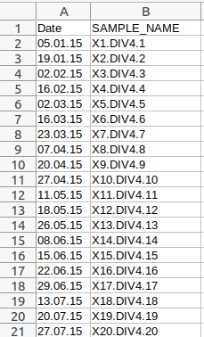

# Plotting one species

This chunk of code can be used to investigate one species in particular. This function is used to produce the plot, given the species name (check that the file is present in the results directory).

```r
# Plotting one species ####

#this function plots one species, given the name of the species and norm = TRUE or FALSE.
plot_one_species <- function(file_name, norm){
  file_csv <- read.csv(file=paste(path_result, file_name, sep = ""), header=TRUE, row.names = 1)
  n_col = ncol(file_csv)-9
  n_row = nrow(file_csv)
  r_n <- paste( "species", 1:n_row)
  r_n <- file_csv[,1]
  if (norm == TRUE){
    normalized_table <- t(apply(file_csv[,2:n_col], 1, function(x)(x-min(x))/(max(x)-min(x))))
    df1 <- data.frame(normalized_table,
                      "row_names" = r_n)
    ylab_text <- "% reads"
  } else if (norm == FALSE){
    df1 <- data.frame(file_csv[,2:n_col],
                      "row_names" = r_n)
    ylab_text <- "# reads"
  }
  df2 <- melt(df1,"row_names")
  g <- ggplot(data=df2, aes(x=variable, y=value, group=row_names)) +
    geom_line(aes(color=row_names))+ ylab(ylab_text) +
    xlab("samples")+ theme(legend.title = element_blank(), axis.text.x = element_blank()) + ggtitle(tools::file_path_sans_ext(file_name))
  return (g)
}
```

The name of the species can be inserted here:

```r
file_name <- "Aulacoseira_granulata.csv"
```

The code produce just a single image.

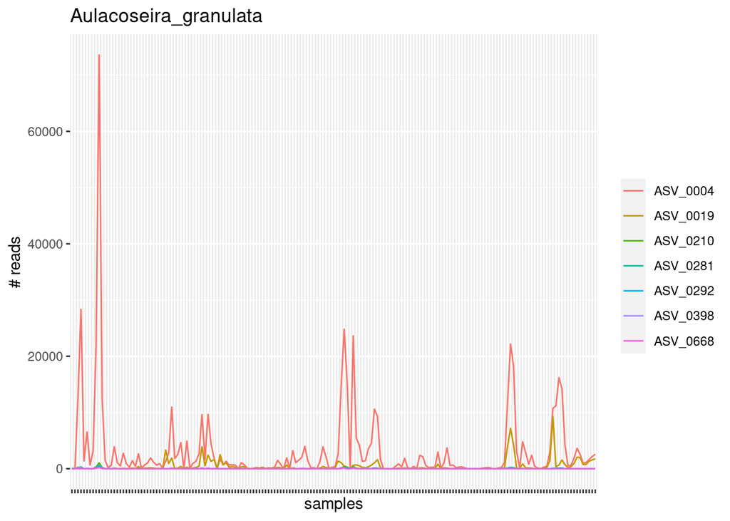

```r
g <- plot_one_species(file_name, norm)
g
```

## Normalization

Instead after normalization, the y axis would range from 0 to 1.

```r
norm <- TRUE
```

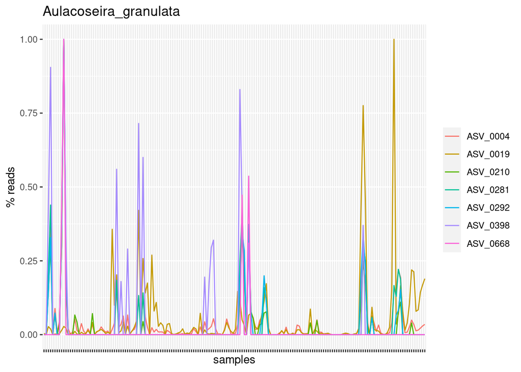

```r
g <- plot_one_species(file_name, norm)
g
```

# Plotting one species, ordered by Date

Adding the **Date** to order the samples on the x axis. Dates are given in *label_file*. Only showing one image.

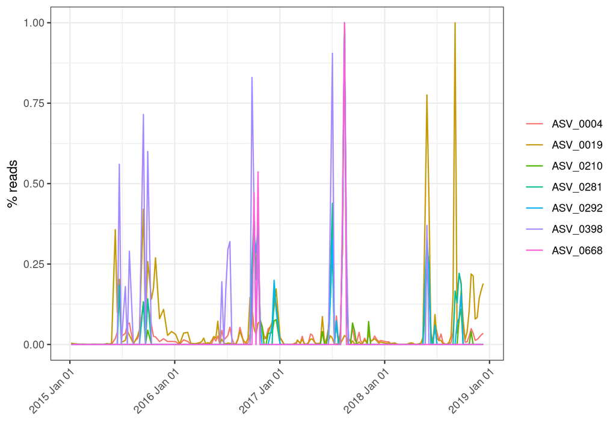

```r
# Plotting just one species, ordered by Date ####

#this function plots one species, given the name of the species and norm = TRUE or FALSE and a dataset where each
#sample name is associated to a date
plot_one_species_dates <- function(file_name, norm, sample_dates){
  n_col <- ncol(file_csv)-9
  n_row <- nrow(file_csv)
  r_n <- file_csv[,1]
  if (norm == TRUE){
    normalized_table <- t(apply(file_csv[,2:n_col], 1, function(x)(x-min(x))/(max(x)-min(x))))
    df1 <- data.frame(normalized_table,
                      "ASV_ID" = r_n)
    ylab_text <- "% reads"
  } else if (norm == FALSE){
    df1 <- data.frame(file_csv[,2:n_col],
                      "ASV_ID" = r_n)
    ylab_text <- "# reads"
  }
  df2 <- melt(df1,"ASV_ID")
  colnames(df2) <- c("ASV_ID", "SAMPLE_NAME", "value")
  df_dates <- merge(df2, sample_dates, by.x = "SAMPLE_NAME")

  df_dates$Date <- as.Date(df_dates$Date, format = format_dates)
  g <- ggplot(data=df_dates, aes(x=Date, y=value, group = ASV_ID, color=ASV_ID)) +
    geom_line() + theme_bw() +
    theme(axis.text.x = element_text(angle = 45, hjust=1)) +
    ylab(ylab_text) +
    xlab("") +
    theme(legend.position = "right") +scale_x_date(date_labels = "%Y %b %d") + theme(legend.title = element_blank())
  return (g)
}

file_name <-  "Aulacoseira_granulata.csv"
file_csv <- read.csv(file=paste(path_result, file_name, sep = ""), header=TRUE, row.names = 1)

#reading the file with the dates
sample_dates <- read.csv(file=label_file, header=TRUE, sep = ",") %>% select(c(SAMPLE_NAME, Date))
g <- plot_one_species_dates(file_name, norm, sample_dates)
g
```

# Plotting one species, ordered by Order

In this case the order is not given by Date, but by the order specified in another column of label_file, called **Order**. In this column the order can be specified by cardinal numbers from 1 to the number of samples.

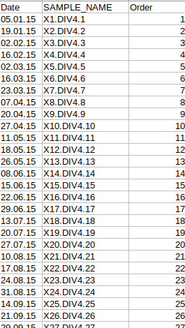

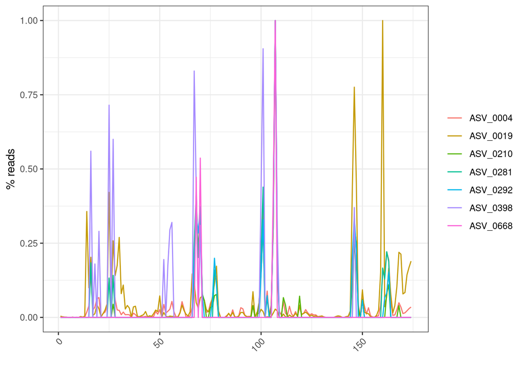

```r
# Plotting just one species, ordered by Order ####

#this function plots one species, given the name of the species and norm = TRUE or FALSE and a dataset where each
#sample name is associated to an order
plot_one_species_order <- function(file_name, norm, sample_order){
  file_csv <- read.csv(file=paste(path_result, file_name, sep = ""), header=TRUE, row.names = 1)
  n_col <- ncol(file_csv)-9
  n_row <- nrow(file_csv)
  r_n <- file_csv[,1]
  if (norm == TRUE){
    normalized_table <- t(apply(file_csv[,2:n_col], 1, function(x)(x-min(x))/(max(x)-min(x))))
    df1 <- data.frame(normalized_table,
                      "ASV_ID" = r_n)
    ylab_text <- "% reads"
  } else if (norm == FALSE){
    df1 <- data.frame(file_csv[,2:n_col],
                      "ASV_ID" = r_n)
    ylab_text <- "# reads"
  }
  df2 <- melt(df1,"ASV_ID")
  colnames(df2) <- c("ASV_ID", "SAMPLE_NAME", "value")
  df_order <- merge(df2, sample_order, by.x = "SAMPLE_NAME")

  g <- ggplot(data=df_order, aes(x=Order, y=value, group = ASV_ID, color=ASV_ID)) +
    geom_line() + theme_bw() +
    theme(axis.text.x = element_text(angle = 45, hjust=1)) +
    ylab(ylab_text) +
    xlab("") +
    theme(legend.position = "right")  + theme(legend.title = element_blank())
  return (g)
}

file_name <-  "Aulacoseira_granulata.csv"
file_csv <- read.csv(file=paste(path_result, file_name, sep = ""), header=TRUE, row.names = 1)

#reading the file with the dates
sample_order <- read.csv(file=label_file, header=TRUE, sep = ",") %>% select(c(SAMPLE_NAME, Order))
g <- plot_one_species_order(file_name, norm, sample_order)
g
```

# Plotting the entire directory. one file for each species

The following chunk of code creates a directory in results called *plots*, then a new direcory called with the same name of *results_dir*. If norm = TRUE, then the new folder is called *results_dir*_normalized.  
For each species (file) inside the directory the resulting image is saved inside this new folder.

```r
# Plotting the entire directory. one file for each species ####

path_plots <- paste(path, "plots/", sep = "")
dir.create(path_plots)

# creating a *results_dir*_normalized folder if norm = True, otherwise only a folder called with the same name as
# *results_dir* inside plots.
# Each plot is a different species with all the matching ASVs.
if (norm == TRUE){
  path_plots <- paste(path, "plots/", results_dir,"_normalized/", sep = "")
  dir.create(path_plots)
} else if (norm == FALSE){
  path_plots <- paste(path, "plots/", results_dir, "/", sep = "")
  dir.create(path_plots)
}

for (file_name in list.files()){ #for all files in the directory *results_dir*
  g <- plot_one_species(file_name, norm) #the function for just one plot is called here
  name_file <- paste(path_plots, tools::file_path_sans_ext(file_name), ".png", sep = "")
  ggsave(name_file, width = 8, height = 4.5, dpi=500)
  printing <- paste("saving plot ", name_file, sep = "")
  print(printing)
}
```

It is also possible to save images ordered by Date (in *results_dir*_ordered_date) or by Order (in *results_dir*_ordered).

# Ordering by Order + separating by Group

To show the output of this last chunk of code, a new dataset is imported. The path and the options at the beginning of the file should be changed:

```r
path <- "/home/valentina_galeone/Desktop/github_rep/metabarcoding/results/"
results_dir <- "poland_seqtab_ASV"
path_result <- paste(path, results_dir, "/", sep = "")
setwd(path_result)
norm <- TRUE
label_file <- "/home/valentina_galeone/Desktop/github_rep/metabarcoding/Data/sample_labels_poland.csv"
format_dates = "%d/%m/%y"
```

Here we are ordering by a **Order** column, and also separating the sample in multiple plots as it is defined in a **Group** column. The plots are then saved in the same image.

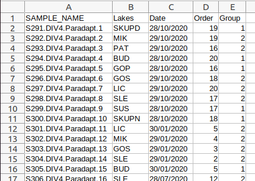

Additionally, a new variable defines the number of columns we wants in the layout of the resulting image. Since we only have two groups in this dataset, the two plots can be plotted vertically, in a single column:

```r
number_column = 1
```

The function to create an image with multiple plots, one for each group, is called *plot_one_species_order_group*.

```r
plot_one_species_order_group <- function(file_name, norm, sample_order){
  file_csv <- read.csv(file=paste(path_result, file_name, sep = ""), header=TRUE, row.names = 1)
  n_col <- ncol(file_csv)-9
  n_row <- nrow(file_csv)
  r_n <- file_csv[,1]
  if (norm == TRUE){
    normalized_table <- t(apply(file_csv[,2:n_col], 1, function(x)(x-min(x))/(max(x)-min(x))))
    df1 <- data.frame(normalized_table,
                      "ASV_ID" = r_n)
    ylab_text <- "% reads"
  } else if (norm == FALSE){
    df1 <- data.frame(file_csv[,2:n_col],
                      "ASV_ID" = r_n)
    ylab_text <- "# reads"
  }
  df2 <- melt(df1,"ASV_ID")
  colnames(df2) <- c("ASV_ID", "SAMPLE_NAME", "value")
  df_group <- merge(df2, sample_order, by.x = "SAMPLE_NAME")
  all_df <- split(df_group, df_group$Group)

  ggplot_list <- list()
  i <- 1
  for (single_df in all_df){
    g <- ggplot(data=single_df, aes(x=Order, y=value, group = ASV_ID, color=ASV_ID)) +
      geom_line() + theme_bw() +
      theme(axis.text.x = element_text(angle = 45, hjust=1)) +
      ylab(ylab_text) +
      xlab("") +
      theme(legend.position = "right") + theme(legend.title = element_blank())
    ggplot_list[[i]] <- g
    i <- i + 1
  }
  return (ggplot_list)
}
```

```r
# Ordering by Order column and making groups with Group column
sample_order <- read.csv(file=label_file, header=TRUE, sep = ",") %>% select(c(SAMPLE_NAME, Group, Order))

path_plots <- paste(path, "plots/", sep = "")
dir.create(path_plots)

# creating a *results_dir*_normalized_ordered folder if norm = True, otherwise only a folder called
# *results_dir*_ordered inside plots.
# Each plot is a different species with all the matching ASVs.
if (norm == TRUE){
  path_plots <- paste(path, "plots/", results_dir,"_normalized_grouped/", sep = "")
  dir.create(path_plots)
} else if (norm == FALSE){
  path_plots <- paste(path, "plots/", results_dir, "_grouped/", sep = "")
  dir.create(path_plots)
}

for (file_name in list.files()){
  ggplot_list <- plot_one_species_order_group(file_name, norm, sample_order)
  name_file <- paste(path_plots, tools::file_path_sans_ext(file_name), ".png", sep = "")
  ggsave(name_file, do.call("arrangeGrob", c(ggplot_list, ncol = number_column)))
  printing <- paste("saving plot for ", name_file, sep = "")
  print(printing)
}
```

As an example, one plot with two groups in just one column (number_column = 1) is shown here

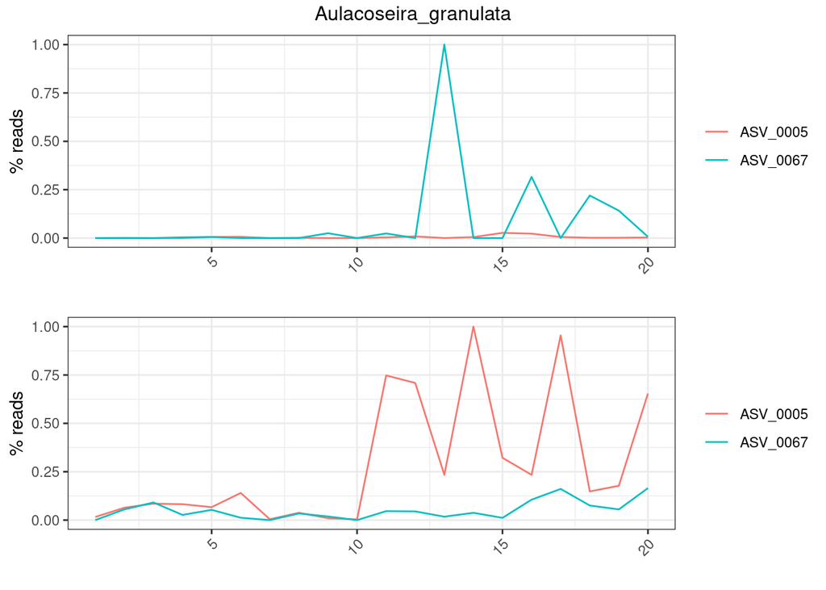